# 1 Two-Dimensional Simulation

## 1.1 State

A simulation is considered complete when it can predict the state $X$ of the drone for the next discrete time segment.

$$X =
[z , y, \phi, \dot{z}, \dot{y}, \dot{\phi}]$$

The state $X$ consists of the coordinates on the z-axis, which points positively towards the center of the Earth, the y-axis, and the vector $\phi$, which describes the rotation angle about the x-axis. Additionally, the velocities, i.e., the rates of change, $\dot{z}, \dot{y}, \dot{\phi}$ of these quantities are also part of the vector.

The thrust $F_{1}$ and $F_{2}$ of the two rotors, in combination with environmental influences, produce all forces that result in changes to the state vector $X$.

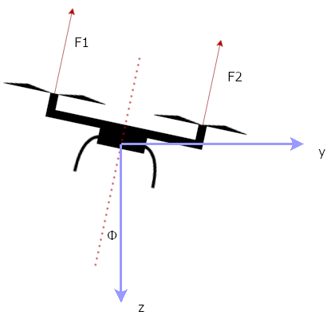

Two-dimensional drone

The thrusts $F_{1}$ and $F_{2}$ are directed at an angle $\phi$ to the z-axis.

## 1.2 Dynamics

Dynamics describe how the state $X$ changes based on $F_{1}$ and $F_{2}$. To work with fundamental quantities, $F_{1}$ and $F_{2}$ are expressed by their underlying rotor velocities $\omega_{1}$ and $\omega_{2}$. The relationship $k_{f}$ between rotor velocity and force is quadratic as shown in . Hence, we have:

$$F_{i}
= k_{f} \omega_{i}^2$$

This relationship $k_{f}$ is determined experimentally as explained in Chapter 3. The changes in state in the positions $z$, $y$, and $\phi$ result from the integration of the velocities $\dot{z}, \dot{y}$, and $\dot{\phi}$. The state changes of these result from the integration of the accelerations $\ddot{z}, \ddot{y}$, and $\dot{\phi}$. These are derived from $F = ma$ and the force of gravity $F_{g} = mg$ with $g = 9.81 \frac{m}{s^2}$:

$$\ddot{z} = \frac{F_{g} - F_{z}}{m} = g - F_{z}
\qquad \ddot{y} = \frac{F_{y}}{m}$$

$F_{z}$ is parallel to the z-axis, and $F_{y}$ is parallel to the y-axis. Thus, there is a right angle between $F_{z}$ and $F_{y}$. Additionally, it holds true that

$$F_{total} = \sum_{1}^{i} F_{i} = F_{1} +
F_{2}$$

The total force of both rotors $F_{total}$ is oriented at an angle $\phi$ to the z-axis.

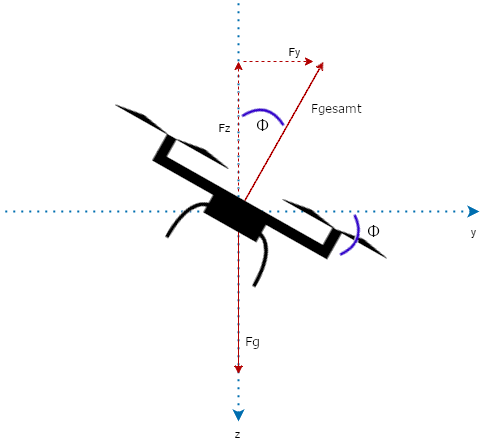

Forces on a 2D drone

Thus, the forces $F_{z}$ and $F_{y}$ result from the triangle’s trigonometry as

$$F_{z}
= F_{total}\cos{\phi} \qquad F_{y} = F_{total}\sin{\phi}$$

and the accelerations along the z- and y-axes by combining Equations [eq:3], [eq:4], and [eq:5]:

$$\ddot{z} = g - \frac{(F_{1} + F_{2})\cos{\phi}}{m}
\qquad \ddot{y} = \frac{(F_{1} + F_{2})\sin{\phi}}{m}$$

$\ddot{\phi}$ is derived through the combination of the equations for torque $M$. $l$ is the distance from the center of mass of the dual-rotor drone to one of the motors.

$$M_{x}
= F_{\phi} l \qquad M_{x} = I_{x} \ddot{\phi}$$

The moment of inertia $I_{x}$ has to be determined experimentally, as described in Chapter 3. The force around the x-axis $F_{\phi}$ is the difference in the two motor forces $F1$ and $F2$ from Figure 1. A positive $F_{\phi}$ corresponds to clockwise rotation, and a negative value indicates counter-clockwise rotation. In summary, we have:

$$F_{\phi} = F_{1} - F_{2}$$

Therefore, the angular acceleration $\ddot{\phi}$ can be described as

$$\ddot{\phi} = \frac{(F_{1} - F_{2}) \cdot
l}{I_{x}}$$

Hence, the dual-rotor drone’s state at time $t$ can be determined by the sum of the state $X(t)$ and the integral of the time derivative of the state $\dot{X}$.

$$X(t
+ \Delta t) = X(t) + \int_{t}^{t+\Delta t}\dot{X}(\tau) d\tau$$

# 2 Three-Dimensional Simulation

## 2.1 State

In the three-dimensional case, the state vector $X$ consists of twelve quantities and is formally defined as
$$X =
[x,y,z,\phi,\theta,\psi,\dot{x},\dot{y},\dot{z},p,q,r]$$

where

$x, y, z$ represent positions,

$\dot{x}, \dot{y}, \dot{z}$ represent velocities in their respective axes,

$\phi, \theta, \psi$, also known as Euler angles, represent rotations about the x-axis, y-axis, and z-axis, and

$p, q, r$ are the angular velocities about the axes $kx$, $ky$, and $kz$ in the body coordinate system.

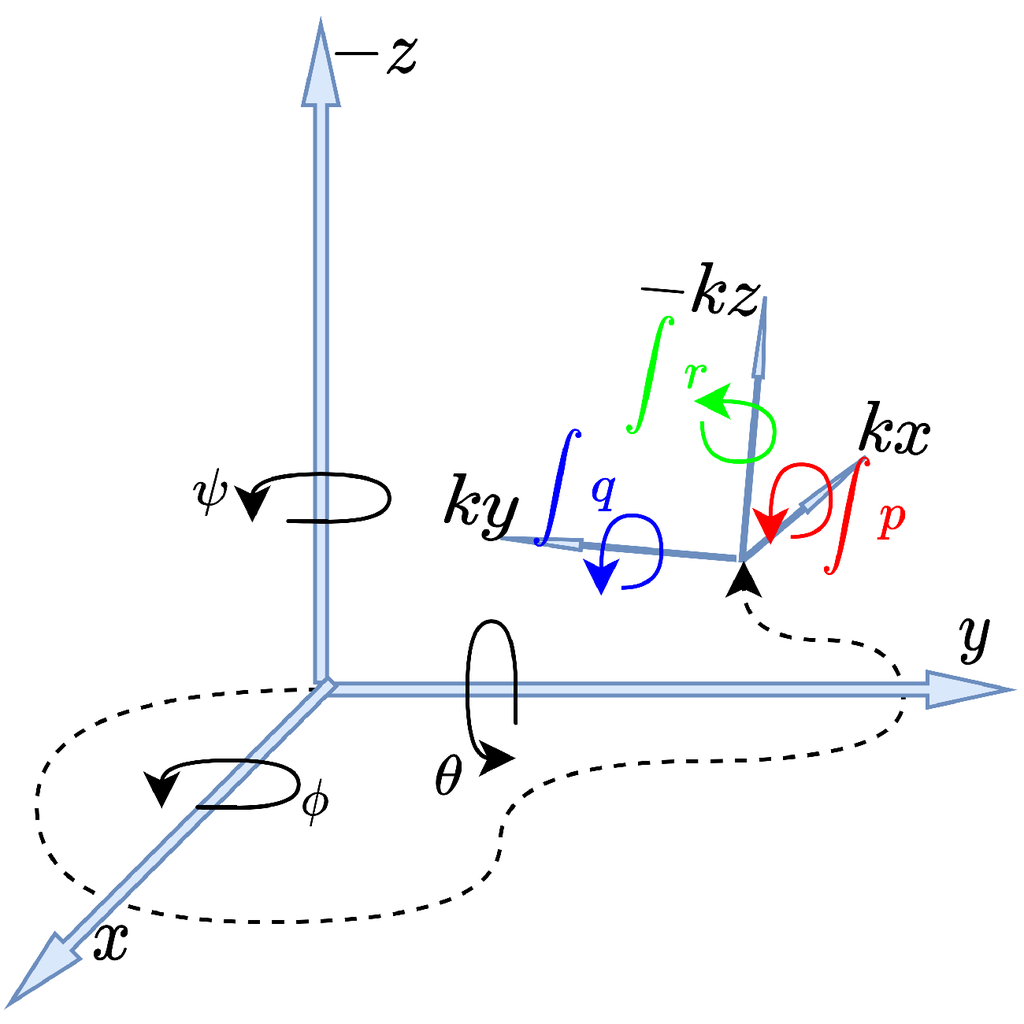

World and body coordinate systems

## 2.2 Dynamics

Equation ([eq:2]) still applies here as before. Analogous to Equation [eq:10], in the three-dimensional case, we also require the derivative $\dot{X}$ of the state vector to move the state forward in time. Equations [eq:3] still apply but now, analogous to $\ddot{y}$, we add the formula for $\ddot{x}$. In summary, still derived from Newton’s $F = ma$, we have

$$\ddot{z} = \frac{F_{g} - F_{z}}{m} = g - F_{z}
\qquad \ddot{y} = \frac{F_{y}}{m} \qquad \ddot{x}
= \frac{F_{x}}{m}$$

Different from the two-dimensional case, however, are the formulas for $F_{x}$, $F_{y}$, and $F_{z}$. Here a rotation matrix is defined , which transforms any vector from the body coordinate system into a vector in the world coordinate system through multiplication. Essentially, the matrix is still based on triangle trigonometry. The matrix $R_{Body}^{World}$ is
$$\begin{array}{rl}
& \left[
\begin{array}{ccc}
1 & 0 & 0 \\
0 & \cos(\phi) & -\sin(\phi) \\
0 & \sin(\phi) & \cos(\phi) \\
\end{array}
\right]
\left[
\begin{array}{ccc}
\cos(\theta) & 0 & \sin(\theta) \\
0 & 1 & 0 \\
-\sin(\theta) & 0 & \cos(\theta) \\
\end{array}
\right]
\left[
\begin{array}{ccc}
\cos(\psi) & -\sin(\psi) & 0 \\
\sin(\psi) & \cos(\psi) & 0 \\
0 & 0 & 1 \\
\end{array}
\right]
\\
& =
\left[
\begin{array}{ccc}
c(\psi)c(\theta) & c(\psi)s(\theta)s(\phi) - s(\psi)c(\phi) &
s(\psi)s(\phi) + c(\psi)s(\theta)c(\phi) \\
s(\psi)c(\theta) & c(\psi)c(\phi) + s(\psi)s(\theta)s(\phi) &
s(\psi)s(\theta)c(\phi) -
c(\psi)s(\phi) \\
-s(\theta) & c(\theta)s(\phi) & c(\theta)c(\phi)
\end{array}
\right]
\end{array}$$

So, from Equations [eq:22] and [eq:23], we derive the formulas for axis accelerations in the world coordinate system as
$$\left[
\begin{array}{c}
\ddot{x} \\
\ddot{y} \\
\ddot{z}
\end{array}
\right]
=
\left[
\begin{array}{c}
0 \\
0 \\
g
\end{array}
\right]
+
\frac{1}{m}\:
R_{Body}^{World}
\left[
\begin{array}{c}
0 \\
0 \\
-F_{total}
\end{array}
\right]
=
\left[
\begin{array}{c}
R_{13}\frac{1}{m}(-F_{total})\\
R_{23}\frac{1}{m}(-F_{total}) \\
g + R_{33}\frac{1}{m}(-F_{total})
\end{array}
\right]$$

Here it is also shown that the propellers generate thrust in the direction $-kz$. On Earth, $g = 9.81 \frac{m}{s^2}$. And the total force now results from the sum of all four rotors, so that
$$F_{total} =
\sum_{1}^{i} F_{i} = F_{1} + F_{2} + F_{3} + F_{4}$$

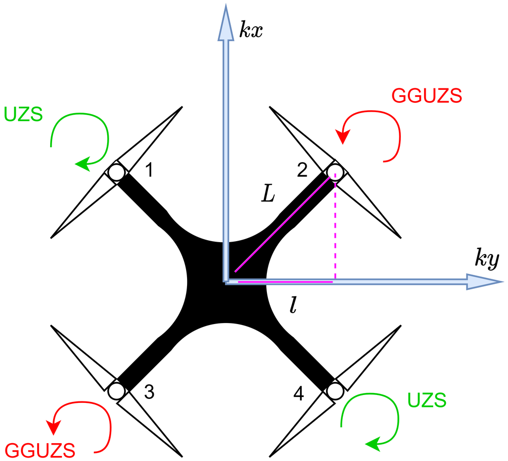

3D Drone from above: Propeller rotation directions and numbers. $kz$ goes into the plane of the drawing.

The accelerations around the body axes $\dot{p}$, $\dot{q}$, and $\dot{r}$ are calculated by the Euler’s equation of motion, which is

$$\begin{array}{rl}
M &= I\dot{\omega} + \omega \times (I\omega) = \\
\left[
\begin{array}{c}
M_{x} \\
M_{y} \\
M_{z}
\end{array}
\right]
&=
\left[
\begin{array}{ccc}
I_{x} & 0 & 0 \\
0 & I_{y} & 0 \\
0 & 0 & I_{z}
\end{array}
\right]
\left[
\begin{array}{c}
\dot{p} \\
\dot{q} \\
\dot{r}
\end{array}
\right]
+
\left[
\begin{array}{c}
p \\
q \\
r
\end{array}
\right]
\times
\left(
\left[
\begin{array}{ccc}
I_{x} & 0 & 0 \\
0 & I_{y} & 0 \\
0 & 0 & I_{z}
\end{array}
\right]
\left[
\begin{array}{c}
p \\
q \\
r
\end{array}
\right]
\right)
\end{array}$$

The moments of inertia $I_{x}$, $I_{y}$, and $I_{z}$ are determined by experiments, as explained in Chapter 3. By rearranging, we then get the accelerations as

$$\begin{array}{rl}
\left[
\begin{array}{c}
M_{x} \\
M_{y} \\
M_{z}
\end{array}
\right]
&=
\left[
\begin{array}{ccc}
I_{x} & 0 & 0 \\
0 & I_{y} & 0 \\
0 & 0 & I_{z}
\end{array}
\right]
\left[
\begin{array}{c}
\dot{p} \\
\dot{q} \\
\dot{r}
\end{array}
\right]
+
\left[
\begin{array}{c}
qI_{x}r - rI_{y}q \\
rI_{x}p - pI_{z}r \\
pI_{y}q - qI_{x}p
\end{array}
\right]
\\
\left[
\begin{array}{c}
M_{x} - (qI_{x}r - rI_{y}q) \\
M_{y} - (rI_{x}p - pI_{z}r) \\
M_{z} - (pI_{y}q - qI_{x}p)
\end{array}
\right]
&=
\left[
\begin{array}{ccc}
I_{x} & 0 & 0 \\
0 & I_{y} & 0 \\
0 & 0 & I_{z}
\end{array}
\right]
\left[
\begin{array}{c}
\dot{p} \\
\dot{q} \\
\dot{r}
\end{array}
\right]
\\
\left[
\begin{array}{c}
\dot{p} \\
\dot{q} \\
\dot{r}
\end{array}
\right]
&=
\left[
\begin{array}{ccc}
\frac{1}{I_{x}} & 0 & 0 \\
0 & \frac{1}{I_{y}} & 0 \\
0 & 0 & \frac{1}{I_{z}}
\end{array}
\right]
\left[
\begin{array}{c}
M_{x} - (qI_{x}r - rI_{y}q) \\
M_{y} - (rI_{x}p - pI_{z}r) \\
M_{z} - (pI_{y}q - qI_{x}p)
\end{array}
\right]
\\
\left[
\begin{array}{c}
\dot{p} \\
\dot{q} \\
\dot{r}
\end{array}
\right]
&=
\left[
\begin{array}{c}
\frac{M_{x} - rq(I_{x} - I_{y})}{I_{x}} \\
\frac{M_{y} - rp(I_{x} - I_{z})}{I_{y}} \\
\frac{M_{z} - pq(I_{y} - I_{x})}{I_{z}}
\end{array}
\right]
\end{array}$$

As remaining necessary quantities to establish $\dot{X}$, which is the goal in dynamics, we have the velocities about the world coordinate system axes $\dot{\phi}$, $\dot{\theta}$, and $\dot{\psi}$. These are obtained, like the linear accelerations in Equation [eq:24] with the help of a rotation matrix specifically for Euler angle velocities

$$\left[
\begin{array}{c}
\dot{\phi} \\
\dot{\theta} \\
\dot{\psi}
\end{array}
\right]
=
\left[
\begin{array}{ccc}
1 & \sin(\phi)\tan(\theta) & \cos(\phi)\tan(\theta) \\
0 & \cos(\phi) & -\sin(\phi) \\
0 & \sin(\phi)/\cos(\theta) & \cos(\phi)/\cos(\theta)
\end{array}
\right]
\left[
\begin{array}{c}
p \\
q \\
r
\end{array}
\right]$$

Thus, the state of the quadrotor at time $t$ can be determined by the sum of the state $X(t)$ and the integral of the state’s derivative $\dot{X}$.
$$X(t + \Delta t) = X(t)
+ \int_{t}^{t+\Delta t}\dot{X}(\tau) d\tau$$

# 3 Determination of Simulation Parameters

In addition to the laws of dynamics, some central quantities also determine the behavior of the quadrotor. These are

$m$ the mass,

$k_{f}$ the constant for the quadratic relationship between rotor velocity and thrust,

$k_{m}$ the constant for the quadratic relationship between rotor velocity and torque,

$I_{x}, I_{y}, I_{z}$ the moments of inertia about each axis.

These constants must be determined experimentally.  
The mass is measured with a bathroom scale. A project member weighs himself and then again while holding the drone near his upper body. The difference gives the mass $m$.  
$k_{f}$ and $k_{m}$ are measured using a seesaw.

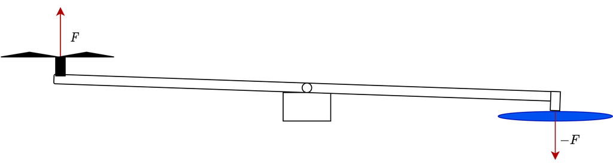

Diagram of Seesaw: Measurement of $k_f$. The kitchen scale is colored blue.

At one end, the propeller is attached, and at the other end, a pin pushes the thrust force onto a kitchen scale. By reading the weight on the scale, the resulting force can be determined.

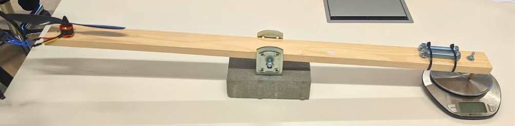

Photo of Seesaw: Measurement of $k_f$

$k_m$ can be measured with a slight modification of the seesaw. The propeller simply needs to stand at a 90° angle to the seesaw.

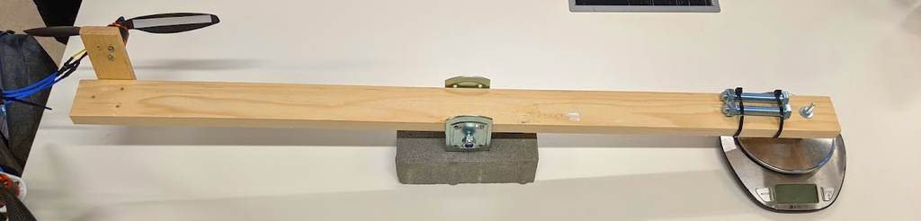

Photo of Seesaw: Measurement of $k_m$

The rotational velocity is recorded by a tachometer. To this end, a reflective strip is attached to the propeller. The tachometer emits a laser and counts the number of reflections per minute.

[figure not shown]

Photo Tachometer: Measurement of $\omega$ with a tachometer

Results of Experiments

| **Measured $v$ [rads/s]** | **Measured $k_f$ [N]** | **Measured $k_m$ [N]** |
| --- | --- | --- |
| 20.00 | 0.56898 | 0.11772 |
| 26.70 | 0.99081 | 0.30411 |
| 35.08 | 1.74618 | 0.37278 |
| 41.26 | 2.43288 | 0.6867 |
| 48.17 | 3.2373 | 0.981 |
| 53.20 | 4.08096 | 1.12815 |
| 58.85 | 4.93443 | 1.30473 |
| 62.41 | 5.4936 | 1.52055 |
| 65.97 | 6.0822 | 1.6677 |

The test series yielded a $k_{f} = 0.00141446535$ and a $k_{m} = 0.0004215641$.  
The moments of inertia are dependent on the weight and dimensions of the drone body. This paper uses results from a publication in which a similar frame of reference was used. Thus we have $I_{x} = 0.0121$, $I_{y} = 0.0119$, and $I_{z} = 0.0223$.